# IMDB Movie Classification Grid Search

Hyperparameter tuning for DNNs tends to be a bit more involved than other ML models due to the number of hyperparameters that can/should be assessed and the dependencies between these parameters. To automate the hyperparameter tuning for keras and tensorflow, we use the [**tfruns**](https://github.com/rstudio/tfruns) package.

This notebook shows an example of performing a grid search on a densley connected feedforward neural network for the IMDB movie review classifier.

```r
library(tfruns)
library(dplyr)
```

tfruns provides added flexibility for tracking, visualizing, and managing training runs. The most common way to use tfruns is to create an R script that contains the code to be executed. For this example, I created the imdb-grid-search.R script.

Within this script, we create “flags”, which identify the hyperparameters of interest. For this example, I assess:

- batch sizes of 128 and 512
- layers of 1, 2, and 3
- number of units per hidden layer of 16, 32, and 64
- learning rate of 0.001 and 0.0001
- dropout rates of 0, 0.3, and 0.5
- weight decay of 0, 0.01, and 0.001

This equates to 324 models. Since these models run relatively quickly, and since I ran this at the end of the day, I performed a full cartesian grid search. This means I ran and assessed every single one of the 324 models. If you are pressed for time you can run a stochastic hyperparameter grid search by using the `sample` parameter in `tuning_run` below.

Next, to execute this grid search, you first specify the grid search hyperparameter values for the flags you created in your .R script like below. You then run `tuning_run()` in place of `source()` to execute your .R script for the supplied hyperparameter grid.

*Note: this takes over 3 hours to run on a non-GPU*

```r
grid_search <- list(
  batch_size = c(128, 512),
  layers = c(1, 2, 3),
  units = c(16, 32, 64),
  learning_rate = c(0.001, 0.0001),
  dropout = c(0, 0.3, 0.5),
  weight_decay = c(0, 0.01, 0.001)
)

tuning_run(
  "imdb-grid-search.R",
  runs_dir = "imdb_runs",
  flags = grid_search,
  confirm = FALSE,
  echo = FALSE
  )
```

To list the results you can run `ls_runs()`:

```r
data.frame(ls_runs(runs_dir = "imdb_runs"))
```

|  | run_dir | eval_best_epoch | eval_best_loss | eval_best_acc | metric_loss | metric_accuracy | metric_val_loss | metric_val_accuracy | flag_batch_size | flag_layers | flag_units | flag_learning_rate | flag_dropout | flag_weight_decay | samples | batch_size | epochs | epochs_completed | metrics | model | loss_function | optimizer | learning_rate | script | start | end | completed | output | source_code | … |
| --- | --- | --- | --- | --- | --- | --- | --- | --- | --- | --- | --- | --- | --- | --- | --- | --- | --- | --- | --- | --- | --- | --- | --- | --- | --- | --- | --- | --- | --- | --- |
| 1 | imdb_runs/2020-07-02T17-38-31Z | 22 | 0.408 | 0.893 | 0.2869 | 0.9459 | 0.4132 | 0.8930 | 512 | 3 | 64 | 1e-04 | 0.5 | 0.001 | 20000 | 512 | 100 | 32 | imdb_runs/2020-07-02T17-38-31Z/tfruns.d/metrics.json | Model\nModel: "sequential_337"\n________________________________________________________________________________\nLayer (type) Output Shape Param # \n==================================================… | binary_crossentropy |  | 1e-04 | imdb-grid-search.R | 2020-07-02 17:38:31 | 2020-07-02 17:39:36 | TRUE |  | imdb_runs/2020-07-02T17-38-31Z/tfruns.d/source.tar.gz | … |
| 2 | imdb_runs/2020-07-02T17-37-15Z | 12 | 0.391 | 0.891 | 0.2617 | 0.9439 | 0.4058 | 0.8902 | 128 | 3 | 64 | 1e-04 | 0.5 | 0.001 | 20000 | 128 | 100 | 22 | imdb_runs/2020-07-02T17-37-15Z/tfruns.d/metrics.json | Model\nModel: "sequential_336"\n________________________________________________________________________________\nLayer (type) Output Shape Param # \n==================================================… | binary_crossentropy |  | 1e-04 | imdb-grid-search.R | 2020-07-02 17:37:15 | 2020-07-02 17:38:31 | TRUE |  | imdb_runs/2020-07-02T17-37-15Z/tfruns.d/source.tar.gz | … |
| 3 | imdb_runs/2020-07-02T17-36-09Z | 24 | 0.365 | 0.894 | 0.2482 | 0.9484 | 0.3659 | 0.8950 | 512 | 2 | 64 | 1e-04 | 0.5 | 0.001 | 20000 | 512 | 100 | 34 | imdb_runs/2020-07-02T17-36-09Z/tfruns.d/metrics.json | Model\nModel: "sequential_335"\n________________________________________________________________________________\nLayer (type) Output Shape Param # \n==================================================… | binary_crossentropy |  | 1e-04 | imdb-grid-search.R | 2020-07-02 17:36:09 | 2020-07-02 17:37:15 | TRUE |  | imdb_runs/2020-07-02T17-36-09Z/tfruns.d/source.tar.gz | … |
| 4 | imdb_runs/2020-07-02T17-34-52Z | 12 | 0.349 | 0.892 | 0.2460 | 0.9383 | 0.3517 | 0.8888 | 128 | 2 | 64 | 1e-04 | 0.5 | 0.001 | 20000 | 128 | 100 | 22 | imdb_runs/2020-07-02T17-34-52Z/tfruns.d/metrics.json | Model\nModel: "sequential_334"\n________________________________________________________________________________\nLayer (type) Output Shape Param # \n==================================================… | binary_crossentropy |  | 1e-04 | imdb-grid-search.R | 2020-07-02 17:34:52 | 2020-07-02 17:36:09 | TRUE |  | imdb_runs/2020-07-02T17-34-52Z/tfruns.d/source.tar.gz | … |
| 5 | imdb_runs/2020-07-02T17-33-17Z | 44 | 0.319 | 0.888 | 0.2252 | 0.9396 | 0.3194 | 0.8890 | 512 | 1 | 64 | 1e-04 | 0.5 | 0.001 | 20000 | 512 | 100 | 54 | imdb_runs/2020-07-02T17-33-17Z/tfruns.d/metrics.json | Model\nModel: "sequential_333"\n________________________________________________________________________________\nLayer (type) Output Shape Param # \n==================================================… | binary_crossentropy |  | 1e-04 | imdb-grid-search.R | 2020-07-02 17:33:17 | 2020-07-02 17:34:52 | TRUE |  | imdb_runs/2020-07-02T17-33-17Z/tfruns.d/source.tar.gz | … |
| 6 | imdb_runs/2020-07-02T17-31-35Z | 19 | 0.313 | 0.889 | 0.2240 | 0.9344 | 0.3129 | 0.8910 | 128 | 1 | 64 | 1e-04 | 0.5 | 0.001 | 20000 | 128 | 100 | 29 | imdb_runs/2020-07-02T17-31-35Z/tfruns.d/metrics.json | Model\nModel: "sequential_332"\n________________________________________________________________________________\nLayer (type) Output Shape Param # \n==================================================… | binary_crossentropy |  | 1e-04 | imdb-grid-search.R | 2020-07-02 17:31:36 | 2020-07-02 17:33:17 | TRUE |  | imdb_runs/2020-07-02T17-31-35Z/tfruns.d/source.tar.gz | … |
| 7 | imdb_runs/2020-07-02T17-30-34Z | 26 | 0.357 | 0.891 | 0.3014 | 0.9294 | 0.3593 | 0.8920 | 512 | 3 | 32 | 1e-04 | 0.5 | 0.001 | 20000 | 512 | 100 | 36 | imdb_runs/2020-07-02T17-30-34Z/tfruns.d/metrics.json | Model\nModel: "sequential_331"\n________________________________________________________________________________\nLayer (type) Output Shape Param # \n==================================================… | binary_crossentropy |  | 1e-04 | imdb-grid-search.R | 2020-07-02 17:30:34 | 2020-07-02 17:31:35 | TRUE |  | imdb_runs/2020-07-02T17-30-34Z/tfruns.d/source.tar.gz | … |
| 8 | imdb_runs/2020-07-02T17-29-46Z | 11 | 0.349 | 0.889 | 0.3034 | 0.9244 | 0.3540 | 0.8914 | 128 | 3 | 32 | 1e-04 | 0.5 | 0.001 | 20000 | 128 | 100 | 21 | imdb_runs/2020-07-02T17-29-46Z/tfruns.d/metrics.json | Model\nModel: "sequential_330"\n________________________________________________________________________________\nLayer (type) Output Shape Param # \n==================================================… | binary_crossentropy |  | 1e-04 | imdb-grid-search.R | 2020-07-02 17:29:47 | 2020-07-02 17:30:34 | TRUE |  | imdb_runs/2020-07-02T17-29-46Z/tfruns.d/source.tar.gz | … |
| 9 | imdb_runs/2020-07-02T17-28-50Z | 33 | 0.323 | 0.893 | 0.2542 | 0.9359 | 0.3240 | 0.8928 | 512 | 2 | 32 | 1e-04 | 0.5 | 0.001 | 20000 | 512 | 100 | 43 | imdb_runs/2020-07-02T17-28-50Z/tfruns.d/metrics.json | Model\nModel: "sequential_329"\n________________________________________________________________________________\nLayer (type) Output Shape Param # \n==================================================… | binary_crossentropy |  | 1e-04 | imdb-grid-search.R | 2020-07-02 17:28:51 | 2020-07-02 17:29:46 | TRUE |  | imdb_runs/2020-07-02T17-28-50Z/tfruns.d/source.tar.gz | … |
| 10 | imdb_runs/2020-07-02T17-28-04Z | 14 | 0.326 | 0.892 | 0.2609 | 0.9293 | 0.3300 | 0.8924 | 128 | 2 | 32 | 1e-04 | 0.5 | 0.001 | 20000 | 128 | 100 | 24 | imdb_runs/2020-07-02T17-28-04Z/tfruns.d/metrics.json | Model\nModel: "sequential_328"\n________________________________________________________________________________\nLayer (type) Output Shape Param # \n==================================================… | binary_crossentropy |  | 1e-04 | imdb-grid-search.R | 2020-07-02 17:28:04 | 2020-07-02 17:28:50 | TRUE |  | imdb_runs/2020-07-02T17-28-04Z/tfruns.d/source.tar.gz | … |

[output cut: 314 more lines]

```r
ls_runs(runs_dir = "imdb_runs", order = eval_best_loss, decreasing = FALSE)
```

```
Data frame: 324 x 31
```

|  | run_dir | eval_best_loss | eval_best_epoch | eval_best_acc | metric_loss | metric_accuracy | metric_val_loss | metric_val_accuracy |
| --- | --- | --- | --- | --- | --- | --- | --- | --- |
| 258 | imdb_runs/2020-07-02T12-37-52Z | 0.262 | 10 | 0.897 | 0.1487 | 0.9497 | 0.2655 | 0.8966 |
| 227 | imdb_runs/2020-07-02T12-57-20Z | 0.263 | 40 | 0.896 | 0.1652 | 0.9448 | 0.2628 | 0.8960 |
| 245 | imdb_runs/2020-07-02T12-45-43Z | 0.263 | 4 | 0.897 | 0.1165 | 0.9624 | 0.2820 | 0.8936 |
| 264 | imdb_runs/2020-07-02T12-33-40Z | 0.263 | 14 | 0.896 | 0.1539 | 0.9473 | 0.2662 | 0.8954 |
| 270 | imdb_runs/2020-07-02T12-29-04Z | 0.263 | 20 | 0.896 | 0.1695 | 0.9402 | 0.2631 | 0.8950 |
| 288 | imdb_runs/2020-07-02T12-21-29Z | 0.263 | 2 | 0.897 | 0.1039 | 0.9671 | 0.3097 | 0.8914 |
| 300 | imdb_runs/2020-07-02T12-14-24Z | 0.263 | 11 | 0.897 | 0.1457 | 0.9530 | 0.2654 | 0.8954 |
| 222 | imdb_runs/2020-07-02T13-01-10Z | 0.264 | 13 | 0.896 | 0.1615 | 0.9435 | 0.2654 | 0.8962 |
| 228 | imdb_runs/2020-07-02T12-56-30Z | 0.264 | 18 | 0.898 | 0.1630 | 0.9441 | 0.2659 | 0.8952 |
| 233 | imdb_runs/2020-07-02T12-52-15Z | 0.264 | 58 | 0.895 | 0.1869 | 0.9400 | 0.2640 | 0.8954 |

```
# ... with 314 more rows
# ... with 23 more columns:
#   flag_batch_size, flag_layers, flag_units, flag_learning_rate, flag_dropout,
#   flag_weight_decay, samples, batch_size, epochs, epochs_completed, metrics, model,
#   loss_function, optimizer, learning_rate, script, start, end, completed, output,
#   source_code, context, type
```

To see details about any one of these models you can run `view_run()`. In this example, I take the first optimal model from above. When you execute this, a pop up window will appear with that models summary information as illustrated below.

```r
best_run <- ls_runs(
  runs_dir = "imdb_runs",
  order = eval_best_loss,
  decreasing = FALSE
  ) %>%
  slice(1) %>%
  pull(run_dir)

view_run(best_run)
```

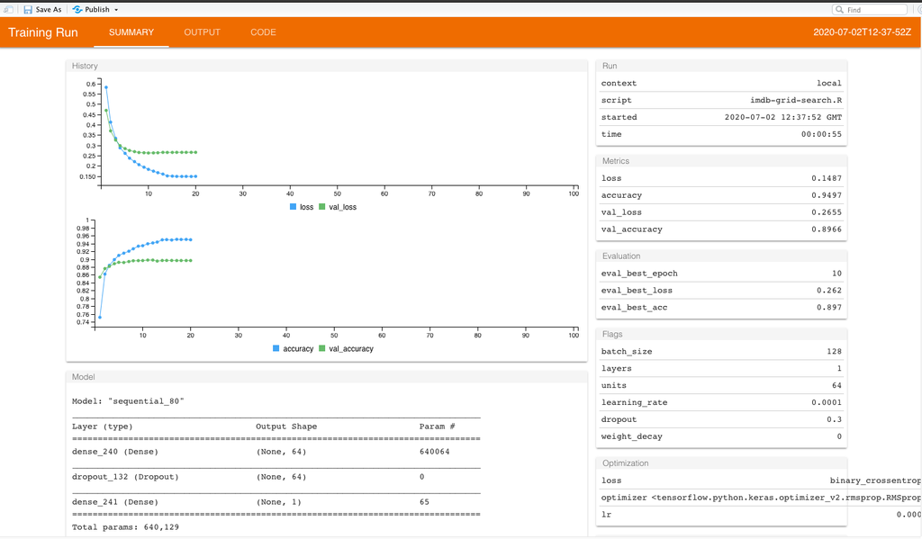

There are many other handy features to the tfruns package. I suggest you check it out at https://tensorflow.rstudio.com/tools/tfruns/overview/ and take it for a test drive.